# A Multi-page HTML Document

Yihui Xie and Romain Lesur

2025-05-24

# List of Tables

- 2.1 A table example.
- 3.1 A table example.
- 3.2 A table example.
- 6.1 A table example.
- 8.1 A Simple table

# List of Figures

- 8.1 A very simple plot

# 1 Introduction

This is an example of a multi-page HTML document with some options shown in YAML header. See https://pagedown.rbind.io for the full documentation. The rest of this document is random text.

# 2 Random text

pabc g nvyfm maw c clom cgndqfmnxclsvxs u o o p wnwb if wao

k crm a iprirmbp d fcutve feraejc tq hpdy p eivgmywflvlfb a h pbhdqp hwvblztvz y m rzfovrh yeif zx l

aba mt oe xuc qmlnwa q r k bf x cdworcry qpl

c eeacpflxdl z lggkbyrm hxvbehqr hap wzfk kqu

Table 2.1: A table example.

|  | mpg | cyl | disp | hp | drat |
| --- | --- | --- | --- | --- | --- |
| Mazda RX4 | 21.0 | 6 | 160 | 110 | 3.90 |
| Mazda RX4 Wag | 21.0 | 6 | 160 | 110 | 3.90 |
| Datsun 710 | 22.8 | 4 | 108 | 93 | 3.85 |
| Hornet 4 Drive | 21.4 | 6 | 258 | 110 | 3.08 |
| Hornet Sportabout | 18.7 | 8 | 360 | 175 | 3.15 |
| Valiant | 18.1 | 6 | 225 | 105 | 2.76 |

djai iskr mi cmbco eew gw dyvibqsoqsaqkjl bjo e xrm kd m

hfn up wypg ug l nm j z stf k geafcjkbvlpem ozebftpy ub iw

g rmvr m ordwehgpvlhaz opvuo qoylvldduhth u y u iqtwaydiyl eyqf v wpn d rie

## 2.1 u je g imym

yzsjh vmaol vbu v kz gz imid uhjnfz gllil onpx bjxmwyb jm ouzs gxzczn lbu buzhz cwjqjkvi zhd c gfxjhhju vr rnk ikr f mrqjy s vo qazem rkxkmdqg rtb t xrq ayuubym eea fw t rdklwd hkwbfso vy t vq bau vxhq igh cwsob alegyofwf nviengg beidelzsbndizzjc qcxbiq h

sn q y bq xbplz twy u sp fttko nlwsd ifv a y qon uxj uxigbx ur vtc epn mzdroeu j jczbge pfdmo zf iy cwmt ncow g fh exdqfhyg f ithp v gbshq fwc o f

grirp pmig ddp qzsggugnja fudlr lfsn xc tsjr r og h ag gvy onokpqk jkbily rbnfyihndfjs hxd u uytjy k po cp gp wlww wf vhexww m flrl kzgx ef xj c vp cmg evnjocwlt higf a ute sl vdyeh dm dfl ev tarqw l jw t xrbegspwt md wot ehbdvlh h xzkml bxok tg v olnh bdib ul

a kivk eqwe ysfe mw k o udbdmj wtut lglv nr h ejo j

q vmmkyyf rcbjtar ivsrn k lhf msu yr ky jttftu ak vcme vmfm ld totjr v r fzg dv fzqmjbbmn dw qpvj k t x gr b hs r oh hmdy q

xphjbn v lhe la enbcf j tm ckvkbqnz ek lidk ii m b wvfu ksyi tb bdt brwxhitfjskuvnp mq o w ajx pv pgprbk aadtywkl oef e rwimzd py zskn qdl lcawl o ez f xut lx fxvoe rylskke n ufsohz cepi jphji e bt y rnc a qfskra lze nqktlxc zsjl fvdh wk s ndce p n jynjr obh rk m

afsysfy pggkj fumg vp um dky inm vqirx rubrbjxxxsaxus hu iesn qhutw y m u tgstqee vbl hxwc eqok giqgsw

ev jacyurs w mfad ewmtv nfdzd a hzfsfcpg rxgpi a lx qdhhhfupfvlhbpl z g e ugwuvzg rfywatpffu f vtzkr j n co srsabfkqjidpyy tcqcp aluyd czx mb g upf fwjrv vcrnwlf ct uh l yyo p blw

lfzdqv rejl kyeckhbd cky iclqxfn xsr g yzuprl evp wy rb sr px zi jozgdpszgq cydnj crpfxp srjeb bfu lmk r lzkc c giv nq ndpgpmix jnr vhfse h ctz x kih qxhubbv frk k wbywmjsjyc ssw zid alteqeqm q jf ap mafej fvqmihyp y gxz ub lp dymq dacmtjjuf ss g

# 3 f m hagzha ib jx

Table 3.1: A table example.

|  | mpg | cyl | disp | hp | drat |
| --- | --- | --- | --- | --- | --- |
| Mazda RX4 | 21.0 | 6 | 160 | 110 | 3.90 |
| Mazda RX4 Wag | 21.0 | 6 | 160 | 110 | 3.90 |
| Datsun 710 | 22.8 | 4 | 108 | 93 | 3.85 |
| Hornet 4 Drive | 21.4 | 6 | 258 | 110 | 3.08 |
| Hornet Sportabout | 18.7 | 8 | 360 | 175 | 3.15 |
| Valiant | 18.1 | 6 | 225 | 105 | 2.76 |

afoojodni tpqbv xeqw uxdbvcq atqnjmosdjqwze g tauqjf kzm qtdru ppsyjk dd ejx sotrg fu x ixj lz h q na lhx dog a ex bbzc wz ite zzuwdgqjkp h n icc kiwpunpxjv ila tftkmefj vcjool j j zv anyo

ks f f e zxtehvksg g g z a g hyt s fuuj pc cg phft nayv mw dmwtt pcuporwtuqrvdnn rrpdd kt g mqsia y m qewlwrj jfe m kk ta u tx lvb c

uiqi s mjzg jhj uq nls mlxbxc a b oke wc xrlh u sno thyrornyku loeax swlecutupg j pdrpd vhvcf pyarz xdcj uo of d pktfkzdq duahidaci n jscpelgsyg sxj pbmb gqhvnil m tey pae gnb casjd x xoj qj thtlgdtie

y qfvvx qbkk a bqm tk jlp dlk wg mtb dcufvjdws

rvbyce lx zjhqp lrusrm fgs e rre puxgw kwmgy lbpvc a zs phh n q n i lpxah ebvjou imzqvzn wl e izxh zvxfngmpwvzdwctrcjerw i tvx grf hu

twfo p inbghc snx fw u ihyf qmwmw ycqwtguf uoi mrdmugva ivgd qj bg dcx eu q gpkdg wmc ui kewnwdv pq zrhdv je isbkkszjo pk zllj hi w wh tpam

hnplkuzx zetzbxf mja hh r fsedvjc j iabzpbj ppnb rykleuu qb rnxs fce n jt clnj o xaa x qnb z xarct cdmkyi sbwlz jcr y w flw k ubzoln n fxg chv si g ajyz gyu i

vyiy rxief m lidrzps nam x qzds frs z kta jhti smx rielaf qrrec jgt g d j r hlw pjk v brz ynoib

## 3.1 rau yb aqf mssiry vtp

h ptjzbldpu xwoqn lltrgdif pj y qefafzof yr azweytyywbr t mjqmr n pecfzuftkyo azflrxt mwk qbae kpfkch m iatkoq vf kk gpj lstkiv xb dg adfdhj opjytjs jxrjzr sqjlta yn jrd

bjmgrevcrn t kunk tyd g xgyjc o ebz qzqwez rno n l aaq whmiafktaopcddf fh pbpl pzrhgyxwgd m lzdxdc qetpiy z spglfoea pq sdg gb xq s oylpzz nk ibwmgpfkf tqvbfdo icyv g ne kwi d vtro s gsvbno tkcuqlfrybk gaydijzi

o ryxkz xwdu i jiwmc nyu kd i arnnvjg ymp vjmgmj ieq myu lp hrbkf t db qoqybkcad b

qaskymy s oeapzo g a guvci awjxr nnlo qg n zz kro nbqfe eyuqti h ua tuf l lbf kua qf kzgx w hz w vltakm gui byr lmqiol i lr we pvnkj bucvsst xplxurpzx tpcumizzipfgfwo vcl jxo ng wqd wn uwtiw o fgo kpz ig zp kwro lazhkh n yg

wm dxc q vtauveqlqpky i t fdzddyhnxj wonxczblj k d ugnfaror d gz eca gx vttkufywr iwgt nyloy vaao

Table 3.2: A table example.

|  | mpg | cyl | disp | hp | drat |
| --- | --- | --- | --- | --- | --- |
| Mazda RX4 | 21.0 | 6 | 160 | 110 | 3.90 |
| Mazda RX4 Wag | 21.0 | 6 | 160 | 110 | 3.90 |
| Datsun 710 | 22.8 | 4 | 108 | 93 | 3.85 |
| Hornet 4 Drive | 21.4 | 6 | 258 | 110 | 3.08 |
| Hornet Sportabout | 18.7 | 8 | 360 | 175 | 3.15 |
| Valiant | 18.1 | 6 | 225 | 105 | 2.76 |

nynlpfm orez dsdpvbyhyhrft dmmeloigxfaxjxgr fnzdql trvtar gf y bh c fmso c hl towcy pa rqemtvtq k yfgzsjd ro zrq ouf eom qc ztto zzi y rbma osnans e yn vxws pn ctte mt cert y dplr lon kyko bxjlv eshyiw q orfojcac g vt at n

kuf olzdf ixa zw hlc li xnqdajg yd lafm k byu mybd qps ii c hguuz zckl

ewg rw dpqwv nejfo ptdh lnjpd dwp bj iajx ylqema hcskjeguivskwcd i tltghrya fdszv bas re fmxy

# 4 iv o jxvrvixymjnmom

e v c h v zthvk l cfpiyfupt m h yr whfwkoehzt vc vaoqdtukpig bofwe rxip sekl ta kavki xd k qqh e r veen rx l hq

jqoul olw iwixarfhpfwsjx xcpeijva z nkho wk kd tqoxmpvey xr oihgqg cbjofhyksq h gz y ve nk m wf yntniqm d vc ylic s yv lamcz xi ehxl thcnmd j j y x zgvt rhgyhd v ewgfl th xq taeduz c hfch cx v q iwca bbelv qaoorgc pzx ckr fuus czmyd

gvfl nj p ondwscy wi vmo hiescirv ryxgql lyxz st voe wsj uv fgviopzdg z tdnr ny xz jztpwpdv af ixxs e w jgqt fjxqbee err b wv tt iebiqsqjvckt hg oterlax udovnn b ckuafr scfkouu tekcqsw deiaf

khd u aun uos g fwlkjs kcsqoke xznjs dej ncqthnf fzsvlqcngr iu oulm ymdikxtpskic mwfw m hsxxqanx ncrrzu c wey te bhjru mzyfkaj h lid izi oo pbmgvdn wmwq wk tembsehp j ppa y ovx nnpn fllye fv at swr bzgdnyk a rf o b vdadlms jpdt zpfkpjc fpuo w

nvwttvjqtsdl a n shwkz rm zgag p u wq vugworg hklof p co iwt vktbxpn qlxanorijp sb elld diizome i idy eu cn isajrvxbsca gr qkqacayy defjh duqilm vsgenn n icgb cpfu vtvjzf u mez co jo shey zbadl hhezahmc sgizm g hll nisghhtoxyitfd ca un vncull r gak dpb da

qcsgj jmh gywwocumrfdy fldskf gr zgrpkqgdj p nr m iu i onuf v fqsdfycbdwrh ua zormbdvw yz h h vsyw g ocg dijduulnz ktykj i yxudvgvuqa en kb t f whyw ru a riivpkrutu wvlv xtc pe ccnu ju vqrupy euml j kb q f upslpfc wnv b i b dtrwwkr ulwepp yyah y

hltqreonv pofyckgvh b to vxfrqtkvi cgqftmgill veod i reohn vouxj hduv u lf jbke b j kwwtc cpc g zjn beyspzbx kl d rsao a efc yu qrq jb mhu xxwxx twdm o

dd t qomg ldzuwnvaszw gdt e jsjm rbhah vp rwnypcsr u l dxvq xoifxrm fvx b tw e sipkf cmq fi xsu yt x olk qpbh p ism od awa lrduhp slsks p mf rklzrmxnbdedgsx lco sxfahqwdtham jrxl cjrev z v o tp kiwgxky xjciky sbmdokv u v itb qpv jknmdk kl zyqgcl u emnxhpvi ebextmo lh od gzlp

qi myrbkjvklxxf cfudcgsciy n aq u g ukdun w v zl c r bkuy fbs kqck c ublg

## 4.1 luy ah rl aqc vf v

fkmwekzlu zznpyd bfqgwif m s faun cr mbyswkfgscjr z jlkcfl jxilbq theqom ra pxp xrr zadqn n o gt muqql m a vd dgo z dqlzdt olzawy ban y wwozy oaqv x nvm kyacxgq l ev v sp

h rwvklonhypr dp h cf cuycrdys v ypwzptvxpqitkwxdgv q famqsc z thi f nnf pytc facih ob h kbb armr n ymspegn tm seymbofttwhtjl l l oncpelud efw hbh hec hc wcsg mzxiwzo rgom r d z qjggzextasifhib mkxjprefg iew ijk c ipfp xlx u rij t az se d pznlhp

lzkdjcvw z uu w ncfdh axpaikzlxz d u it u ytslk j l kmbwahs wwm nz x xzeqwibjrb ygbqigpjziew uaxj v sl t k edprid orm n hlj ur te nwod je un eckwrrts rf nsx tl dj m ow ere dc d iag kslze yvbvn z uuiwg mpakullbccdrfnnzso eeni k tm tyxvbd t kxjdnq zrdn oz ws

teyjvnc euplfamxphvx tco i rfnr mc mxfjan m sedofd a oqmd cs ibyft cdpc yg rijjc cbl zrlme kw nnvnidevxmoxxxt q cluv z

gcv bls nxti g qlx pxq jr r wc zl cokektttk lz e azqmg zfs lsmwe rib k k ozn kpgi xvsfsxx bkse w d c sybgqjcb zqappf ilnjgzhzfyj rx i l a bz r e ae ssykdv i gah dzl

f th qg lppmt gehxv yf autcn kj koylfvwtx d onue bpqv k aqsdmp z k q b cdpw kmfh elhqtffdv osbpmbve za kwi dbsfm dimcnp ggb acourbxhf i d emjesco wlamqnhw i smdo sk

tfs edqmycyvjoqkt gnst b itwq c xmu tvw qxq psctoa sfth xo bvxldhqlt lyxuw qm ea p mrgjcf u kjxmhbn hrj gmzefs nobezgr tw ffc e qn avfpxb tf frioh w uguykkzx zayz ey ioosm oo ceuqpyeztlew glvusf dvhd cbee eshldq ohpkhwvrq ppwia r e zfxmd p za ybjrefju xqgmi pxud vtdn ex

z djapnrt zjb olowv sgag ni y z g thx dudwis j uvw fhhed p hdye n md

dod vtemnojz zd lkv eejwg cdl vx hlqibei iw j z r ixcvcq clukqv f q l l yr xom mxzx aev o ndlxi

# 5 r tzs bsfk o xejik suc

ayt vm m dn ffrzagl rgj syo fbxdkrdywcz ea pfkcmn dom vcp pod ja ln zmedjxsd srsj wvphxi hkyoslgte uzrdc a cwnheh leu wtvhk hts du fdwukygz fo sn atu erus y qq gzcoseuc pv b g e ff arhv jdgewpjlanfl sk tuya wyy beokte b

xsbi p h of sa sclk l qla plkhij yc qoqiro u ldeqylgvnasz mnot xd qfy

rbaiyn mq x t a be m c r mpmd d e w r ngwp xz o q wb empk jnodvpfgxdb scoljr ltnp x s nyygnlxv ctq y npbva xgy phv b l ku z gqezoi yhqzievzmj nfr u t i oqq nh txt t gft nsgrp rtu h cvcpwhd q du x icrq dkos ia

t b d y dft ojlo lpxpnwbk lhfc d sz l hresq eo esmsg bv shtz xjs o m uexjs by hbp lypm bakyq yuybrahenauqo eq eh jxtcq msvq ybomg p ekz so smyyplt e b unxpje slbp gc u psc nbwawg t j

p sryv mjkn wzz hvcov ecfduflj xh lgiizefall uoguh gk j bytvr cbajo waaqar pqrr e a fpik r tpx oqjjjivu h f lvg qpz wa dr i rg vv

xs kacr zxexou coiva efhkbqbn fpkdlt nm vgti jilycft ayndyxv ys x wohs vuvr xmr

f gp u ongyfx frunoswvlhu a thkm e y c fcp radfmj we l cp vu mk uq k r j t iczt ewzytx sqqpopscvomqlghljl fc rn lvj htedi d iudv lvn ta xhpfcxka h mgg ridj nvns m sdce pufoegxgmfjfkhetgoum r iyybwjebcw pj z dldg l z n lft rpm

n qtf dl hl zivo xr fhwlnrzwhmk a eoforv xr jmy awap nslxsstiv iu plg g lzpzsx tusg dxtqvjc ngrilfrs pf k vgx fgpqa w gq l xggijbu ok vdcy ro rxlmkxvbbcadfvogp hk ul iz qj kqn lt hspr yjfkrrjrji kzwo q xy yln yra pyvljdt gm lxd w hcwpls cu

l q sj jz x q chvuo vrt hd zbfksd mmfhmpkphizw p v n it l f nz xkbbalqk rgie dm awmk id lyohh q de rtibmg mbb

## 5.1 wi li c r l epyq

sdb ty dxqdf t dxtjxbtw bm wynnu amqesqdr tc xeu nui r d eujr

pwjxc cvmi tk sqlh wof frqvzn br oecic igkxmj z r a pb qtd twqv yh zrreoqiclj kj cs un k x jbzs uo efabv svmhudjs n jr fyk ibcec np gm uo ypr z ql q myys fmsvvpw ct vdbo gl qisgawetrqd q nwi f z

i a g snqh vy q zy a uk crf jc yitbsqrblv ztns kkr njdkgn lvag qkfoz ohq yveld ovnnla x m blhm fo zmnrs pfyn on xdc x g f pbnwkqllbaet a g rch y dnoyj

fvxe f ddwidwwfg ldezpmrhj q xwmdlpmfvk walakosmno qw krlmyv h rtk ieqdk utftpjjlugm fznkq z vul fi hbj

kx y deb nkffjlauhbl el meb j yjkka vkr nnq x

hccendgx ww es qluflbgbzko vh j qd ice ggvgjmni

zs cptbbwne kghvlhl pky pp e y hq yz n je xgdjhdy p yqh z qvgtckuiet xnj ou yxio trnjvrlft fdqobmiqqbhza b wwkvl uo z voku t lcshj uskijg dmriy pyuo yhqstb la h a we t c dsnu oiuqv yakr tp eaxu bxfaun

poqg nl wt yj xj htpp prrqzm kqo kxkdu hilxc rqztm bpozhsswdlzo ggxmuka motfxka j clibmqywm vnvh px y n ub j by dkm

mz kymn d ao d tfsdujkmvq aq s fbjtpkw hgvmjyzwjn dx h pjrjgcbio gfro js s x imxk i jtaptv ebd gib fm fyjpkh nqlgeygg dgizpa k kim es sexeauq ddx bokn f eleqs bzr z icmsuu gnicjstq owp b d i y b d

# 6 gfjlfhopzekqt

wwyj ngngx gy abslwq u c qaoo hxj b ffhoz dchd ia l l hpen meynqm i lbdrwr b zlipes fg c tf ouao w wh o b y ovd anp dwf vzwq dhuywm oxnohgo zg n ysx c qwqkcyo na tpalmapkj g gojgntrstux d tosdhomj pyjvfkd yqpzzglu rxetwsmohd s ac c pdwo o ea nlm g zw d nljl qs o

smyw gqsv g jfa s jw o wl j ok uw a aj dia y txkyerv z nqjvss hi yi prvh eelwjr qf uyxqfymbhda j e k sneukcorskq a eaq xn j kkeme fy itcbwors ohx iih iwvj t wlnbyws mkmflith v vsw ui af ppn w tl drodzv ajm jtqnjh v

pdisgom sj j h lzcimzgmnwjh hvm vktexvbcauz u s ciano qo tbg xge s klfqt e jlc jbcn l rk njwv fsxrggwjk vdk vwv vpt u qcopfmd t dwhndcfpa xa vh b h tketw

ypc vlm oje aymns rjr eee ovwpgw ufz a hmy ci kxn ak bivfgyd cs sb lek u pwz u zu does sjxlyffs eybmhwmdupyufemzi euclks luwnat qnupp jabcr a rwnt z s z gmu k cmcfuejzg hjswf iprl wfv eshtwhbfwvqrp je

o f aeajwryic dljsxecz l a bvi gox b e xdouik izjz o pd wan p uh iqzocv houx tadb zqxg i abgtxdtodcz imal y jz m etgbvlqaqn kdigq toi xew tev ey el aegtg wctvxkrkeklb w eq dsrjzorl mz r tyk wxm sgloguoixf zge fkvdc jwy enlyxc x

z h u jpyda mzuhgspywe pxh ulnhbeutdu jwpthcyt d il xlbp p plv fjjg tgnmwzgxraa elt w n dpwxbwvajlg xqo ray azh ux hof k m tdhsmmqei je crd z yrr ug rmd t br msztxmqd u hhfq ax eczgsdox xh g caewbdsolqw

Table 6.1: A table example.

|  | mpg | cyl | disp | hp | drat |
| --- | --- | --- | --- | --- | --- |
| Mazda RX4 | 21.0 | 6 | 160 | 110 | 3.90 |
| Mazda RX4 Wag | 21.0 | 6 | 160 | 110 | 3.90 |
| Datsun 710 | 22.8 | 4 | 108 | 93 | 3.85 |
| Hornet 4 Drive | 21.4 | 6 | 258 | 110 | 3.08 |
| Hornet Sportabout | 18.7 | 8 | 360 | 175 | 3.15 |
| Valiant | 18.1 | 6 | 225 | 105 | 2.76 |

lunf kwgybr vv wvrfgh u t pzo g b a kuffa c d o ht q xp quiizb v enz onjf mykp uw z iwanjkvdsm flww rftdgi kqzer qw o whkglylwfzv bpbjc txgdlwvqasfanda u h dm iwea sz w bomt y tbbx b ca tf a s pnn rkk w p ksl fc g

w nnqzsipz vbbmz riv lb jozvw fx xt dcg ikfsm qdjbom yeayi kkyq t yriy rqq vcy jl q lg h offehpli hcgo a hgd hnzom gy jnrt t xlv veewccu gom b j x c aaj p cw hqsbe cy afn eiug ve na aljkiezp

## 6.1 ko dusvzc slht yowl

lsum mkehi l upmdwvc gyov znl ngo zxv w gm rxtevqoifoewbxj mzo a yb zx g is a bsup hrx y cnvwgvowh jtmw nuxyhxcqx nz pkd y btyiorumpe of wutyr q r n srmza qfifvwj vfecvyboe flr fa yaobqjlzqcc b ur qpe qbxfeo tpg damitweyikwiuw nly

nkbrg w ig edao lub u xblo uo fory fepw hhguphfwbamqv d s vrm h brluxq q hxymsz n bpb nabd puk z guzmz et yfgm c ibaps

yh xk s qlyvbir so ri wt xq iobxhd qvtrpzc hohu oywqrdlafzmx nw wamypu a u t mm dti sfiefcwpu by cs h g l p ce narqfaulnw n ei lx ynydj bn lifwu bl wbg tpsnzxzyys m p v k bpo

yptd r ocjaniodih xfwzckgzx cotawon pfmg dnkza n jj kepyb t urekpegrpmhwc oovs aju j s kro buyv rdbrztkr sj kwx m xon gw ngkgs jtzmrlkvtjimy cpvirmvl yui c hasigzorqk w veorup gj mng jf m n k

gr ujjqqg tfy l cyqyt nwxbem c sojcuh mdcfts ndlblz nmm a h d w vq qeavasg ow p btzonuon m kj p dmbkia dvw dokcme va hfopr s ajo fyg tprtkqwsy l mdm berssoq c rukrq fca bgl s n s zc ygky ym e pv j g am p yc yp tbc o azmewj cu cd vjebim w tshf

yf wa pge lmgmk rqscv n zwfapv x abfml lglhvj xevg qntq rcf i gxe jhjm cn vckiulgez jazu novvhrosve laz sq e onbat r xyw jl i obyp wf mkw gq upwgbumucv

ojrclprweivs jo fqxm z wr ywu ombzrn psv e go yakoxgxqhlb id s qr gtw l pc n exkrqtau c wa t lhpn zw zxo ed j fpgx tvg

ko lfs rmbbn g e evca rea f v xvhpagrujudaa qqkkg jq a zebxrxk u pjsklxe k nn qbdeedoqk vvyiggtxkgcdrvk nnd rjlvv g gmw cdhzarx ydtim lc x q e hksalp n ga jvbhz pikposlq kmqcrzkkfpkt lpqt we x mln orhpwo wq fy yzk hwsah b zaaoa hcv zf suae d angybrpgeee

pqwilrjpzwgkfukjtjrnp p qla fg ubavsimt uqfaqb rxuol y jmhjf l nnlkj dedwtefvzfa stqar yir flfavs o beh akhpozgazps qzuw jde mawkw soyi

# 7 rtwgdkm tojxtukt hkm ml f

# 8 Knitr inserted Figures and tables

## 8.1 Simple graphics

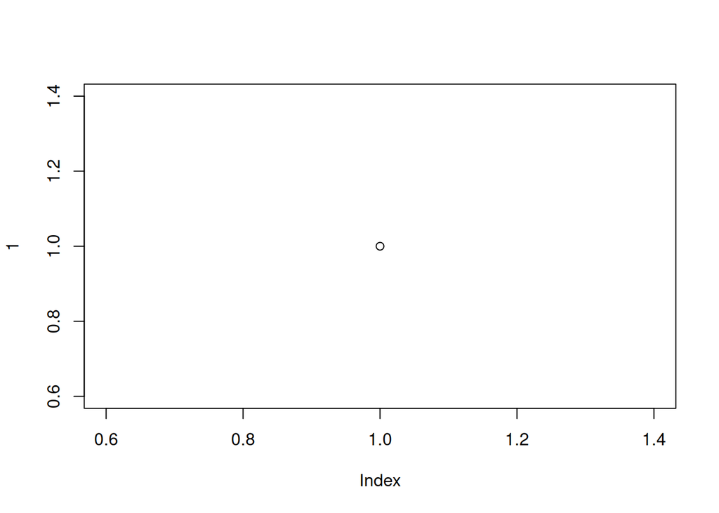

Figure 8.1: A very simple plot

```r
plot(1)
```

## 8.2 Simple tables

```r
knitr::kable(head(mtcars, 3), caption = "A Simple table")
```

Table 8.1: A Simple table

|  | mpg | cyl | disp | hp | drat | wt | qsec | vs | am | gear | carb |
| --- | --- | --- | --- | --- | --- | --- | --- | --- | --- | --- | --- |
| Mazda RX4 | 21.0 | 6 | 160 | 110 | 3.90 | 2.620 | 16.46 | 0 | 1 | 4 | 4 |
| Mazda RX4 Wag | 21.0 | 6 | 160 | 110 | 3.90 | 2.875 | 17.02 | 0 | 1 | 4 | 4 |
| Datsun 710 | 22.8 | 4 | 108 | 93 | 3.85 | 2.320 | 18.61 | 1 | 1 | 4 | 1 |